```python
%matplotlib inline
import matplotlib
matplotlib.style.use('ggplot')
import matplotlib.pyplot as plt
import numpy as np
import pandas as pd
#td stands for titanic data
td = pd.read_csv('titanic-data.csv')
td.head()
```

|  | PassengerId | Survived | Pclass | Name | Sex | Age | SibSp | Parch | Ticket | Fare | Cabin | Embarked |
| --- | --- | --- | --- | --- | --- | --- | --- | --- | --- | --- | --- | --- |
| 0 | 1 | 0 | 3 | Braund, Mr. Owen Harris | male | 22.0 | 1 | 0 | A/5 21171 | 7.2500 | NaN | S |
| 1 | 2 | 1 | 1 | Cumings, Mrs. John Bradley (Florence Briggs Th... | female | 38.0 | 1 | 0 | PC 17599 | 71.2833 | C85 | C |
| 2 | 3 | 1 | 3 | Heikkinen, Miss. Laina | female | 26.0 | 0 | 0 | STON/O2. 3101282 | 7.9250 | NaN | S |
| 3 | 4 | 1 | 1 | Futrelle, Mrs. Jacques Heath (Lily May Peel) | female | 35.0 | 1 | 0 | 113803 | 53.1000 | C123 | S |
| 4 | 5 | 0 | 3 | Allen, Mr. William Henry | male | 35.0 | 0 | 0 | 373450 | 8.0500 | NaN | S |

# Possible factors that will influent Survival Rate

1. Pclass may have influence on survival rate- the closer the class is to the safeboat, the higher the survival rate
2. Sex will also affect survival rate, wemen will have a higher survival rate
3. Age will also affect rate, children may have a high survival rate
4. SibSp and Parch may also influence survival rate, but not sure about it
5. Fare may also have effect,similar with Pclass
6. Embarked region may have different survival rate All these are possible factors i'll examine.

## Take a glimpse of the Data

```python
td.isnull().sum(axis=0)
```

```
PassengerId      0
Survived         0
Pclass           0
Name             0
Sex              0
Age            177
SibSp            0
Parch            0
Ticket           0
Fare             0
Cabin          687
Embarked         2
dtype: int64
```

```python
td.dtypes
```

```
PassengerId      int64
Survived         int64
Pclass           int64
Name            object
Sex             object
Age            float64
SibSp            int64
Parch            int64
Ticket          object
Fare           float64
Cabin           object
Embarked        object
dtype: object
```

# some changes of dataset in later code

As we can see from dataset above , 177 data missed from Age, 687 data missed in the Cabin column, and 2 data missed in the Embarked column.

here are some changes i'll make during the later sections.

> Age value with null values will be abandomed when calculating Age affect on survival rate

> since Cabin is not a factor i'm concerning, the column will be used

> 2 values missed in the Embarked column, here are two ways of handling this situation. A: abandom these rows. B:replace the null values with most common ones, namely "S". I think take the first option might be better, since 2 value won't cause significant changes to dataset

> SR stands for **Survival Rate**

# Test single variable influence on the Survival Rate

## compare Sex on survival rate

```python
#compare women and man survival rate
Sex_on_SR = td.groupby("Sex").sum()['Survived']/td.groupby("Sex").count()["Survived"]
Sex_on_SR
```

```
Sex
female    0.742038
male      0.188908
Name: Survived, dtype: float64
```

## compare Pclass on survival rate

```python
#compare Pclass survival rate
Pclass_on_SR = td.groupby("Pclass").sum()['Survived']/td.groupby("Pclass").count()["Survived"]
Pclass_on_SR
```

```
Pclass
1    0.629630
2    0.472826
3    0.242363
Name: Survived, dtype: float64
```

## compare Age on survival rate

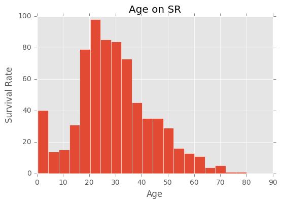

```python
m= td["Age"].sort_values(ascending = "true")
ax = m.plot(kind="hist", bins =20, title='Age on SR')
ax.set_xlabel("Age")
ax.set_ylabel("Survival Rate")
```

Age varies alot, as we can observe in the above graph, i consider to categorize it into four groups

> children

> young

> middle

> old

And as we can see, there are also 177 null values ,i'll drop these values off. Here is the process

for age below 19, i'll group them as children, for age between 19-29, i'll group them as young, for age between 30 to 49, i'll group them as middle ,for age more than 50, i'll group them as old

```python
#compare age effect
def ageeffect(age):
    if int(age) in range(0,19):
        return "children"
    elif int(age) in range(19,30):
        return "young"
    elif int(age) in range(30,50):
        return "middle"
    elif int(age) in range(50,100):
        return "old"
    else:
        return "not known"
td_fix_age = td.copy()

td_fix_age= td_fix_age.dropna(axis = 0,subset=["Age"])
td_fix_age["Age"]=td_fix_age["Age"].apply(ageeffect)
td_fix_age["Age"].count()
```

```
714
```

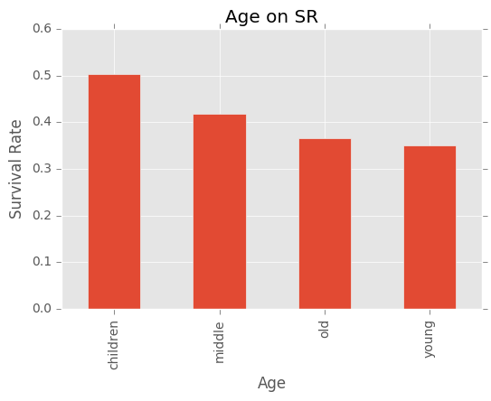

```python
Age_on_SR = td_fix_age.groupby("Age").sum()['Survived']/td_fix_age.groupby("Age").count()["Survived"]
ax= Age_on_SR.plot(kind="bar",title ="Age on SR")
ax.set_xlabel("Age")
ax.set_ylabel("Survival Rate")
```

## compare family on survival rate

In my opinion, SibSp and Parch represent whether passanger has menbers on board, so i'll change the data as following

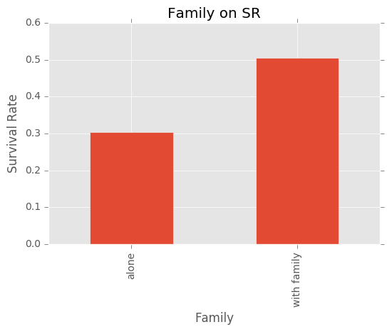

```python
td_family = td.copy()
td_family["family"]= td["SibSp"]+td["Parch"]
def withfamily(i):
    if i>0:
        return "with family"
    else:
        return "alone"
td_family["family"]=td_family["family"].apply(withfamily)
td_family.head()
td_pic = td_family.groupby("family").sum()["Survived"]/td_family.groupby("family").count()["Survived"]
ax = td_pic.plot(kind="bar",title = "Family on SR")
ax.set_xlabel("Family")
ax.set_ylabel("Survival Rate")
```

## compare Fare on Survival Rate

```python
td["Fare"].describe()
```

```
count    891.000000
mean      32.204208
std       49.693429
min        0.000000
25%        7.910400
50%       14.454200
75%       31.000000
max      512.329200
Name: Fare, dtype: float64
```

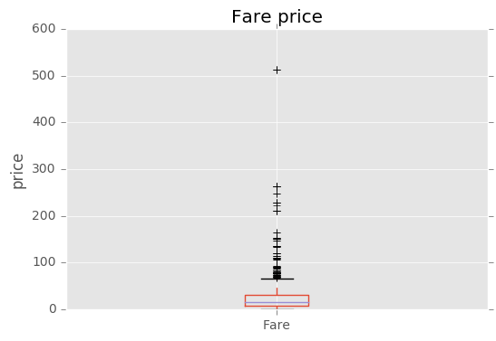

```python
ax= td["Fare"].plot(kind="box",title="Fare price")
ax.set_ylabel("price")
```

from above graph we can see that though average ticket price is low , there are alot outliers , so i'll group them into different quoters as below

```python
def fareclean(p):
    if p <= 7.910400:
        return "firstQ"
    elif p <=  14.454200:
        return "secondQ"
    elif p <= 31.000000:
        return "thirdQ"
    else:
        return "forthQ"
td_fix_fare = td.copy()

td_fix_fare["Fare"]=td_fix_fare["Fare"].apply(fareclean)
td_fix_fare.head()
```

|  | PassengerId | Survived | Pclass | Name | Sex | Age | SibSp | Parch | Ticket | Fare | Cabin | Embarked |
| --- | --- | --- | --- | --- | --- | --- | --- | --- | --- | --- | --- | --- |
| 0 | 1 | 0 | 3 | Braund, Mr. Owen Harris | male | 22.0 | 1 | 0 | A/5 21171 | firstQ | NaN | S |
| 1 | 2 | 1 | 1 | Cumings, Mrs. John Bradley (Florence Briggs Th... | female | 38.0 | 1 | 0 | PC 17599 | forthQ | C85 | C |
| 2 | 3 | 1 | 3 | Heikkinen, Miss. Laina | female | 26.0 | 0 | 0 | STON/O2. 3101282 | secondQ | NaN | S |
| 3 | 4 | 1 | 1 | Futrelle, Mrs. Jacques Heath (Lily May Peel) | female | 35.0 | 1 | 0 | 113803 | forthQ | C123 | S |
| 4 | 5 | 0 | 3 | Allen, Mr. William Henry | male | 35.0 | 0 | 0 | 373450 | secondQ | NaN | S |

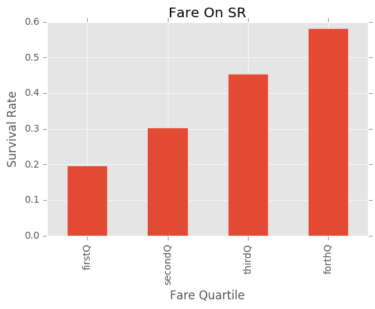

```python
Fare_on_SR=td_fix_fare.groupby("Fare").sum()['Survived']/td_fix_fare.groupby("Fare").count()["Survived"]
Fare_on_SR= Fare_on_SR.sort_values(ascending = True)
ax = Fare_on_SR.plot(kind="bar",title="Fare On SR")
ax.set_xlabel("Fare Quartile")
ax.set_ylabel("Survival Rate")
```

from above graph we can also see a trend between ticket price and survive rate. As price get higher, survival rate also get higher

## compare Embarked on Survival Rate

```python
td.groupby("Embarked").sum()['Survived']/td.groupby("Embarked").count()["Survived"]
```

```
Embarked
C    0.553571
Q    0.389610
S    0.336957
Name: Survived, dtype: float64
```

# A more deep dive of the Survival Rate

From above graph as analysis, we can see that

1. Pclass have influence on survival rate
2. Sex also affect survival rate, Female have a higher survival rate than male
3. Age also affect rate, children have a higher survival rate, people between 19-30 have the lowest survival rate
4. SibSp and Parch also influence survival rate, people with family will increase their survival rate
5. Fare also have effect, higher the ticket price, higher the survival rate
6. Different Embarked region have different survival rate, peopel embarked from C has the highest survival rate.

## In conclusions

1. The result of Pclass and Fare on Survival rate are consistent with expection, since Pclass =1 is in upper level of the ship, which is closer to the saveboat and when ship sinks. These people could have more time to wait for rescue or get on saveboat.
2. Sex and age are also greatly influent the survival rate , since rescue female and children are the first priority
3. passenger who has family members are more likely to survive.

### another question raised from analysis

why peopel embarked from Cherbourg has the highest survival rate.

```python
class1 =td[td.Pclass == 1].groupby("Embarked").count()["Pclass"]/td.groupby("Embarked").count()["Pclass"]
class2 =td[td.Pclass == 2].groupby("Embarked").count()["Pclass"]/td.groupby("Embarked").count()["Pclass"]
class3 =td[td.Pclass == 3].groupby("Embarked").count()["Pclass"]/td.groupby("Embarked").count()["Pclass"]
class_embark = pd.DataFrame({
        "class1":class1,
        "class2":class2,
        "class3":class3
    })
```

```python
class_embark.head()
```

| Embarked | class1 | class2 | class3 |
| --- | --- | --- | --- |
| C | 0.505952 | 0.101190 | 0.392857 |
| Q | 0.025974 | 0.038961 | 0.935065 |
| S | 0.197205 | 0.254658 | 0.548137 |

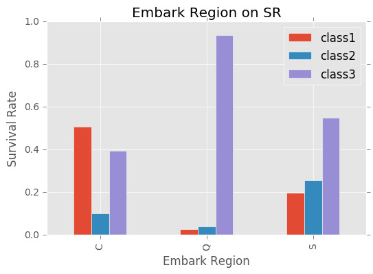

```python
ax =class_embark.plot(kind="bar",title="Embark Region on SR")
ax.set_xlabel("Embark Region")
ax.set_ylabel("Survival Rate")
```

As we can see from the graph, people get on board from Cherbourg are major in first class ,thus have a higher chance of getting to save boat and get rescued

# conclusion&limitation

from the data, we've seen that most outcome are in consistent with our expectation, however , as we can see, 177 values missed in the age column, we simply abandomed them , and get our result . What if 177 values are not null, the result could be totally different from our previous outcome.